Guatemala · 29–30 de septiembre de 2026

# Del instrumento al sistema: *proteger trayectorias*

El IAFREE-A como escucha calificada, y el SPTE como la experiencia brasileña de ir del diagnóstico al apoyo a la intervención.

Encuentro Nacional de Innovaciones para Proteger y Recuperar Trayectorias Educativas · Casa Ariana

**Leogildo Alves Freires, PhD**Universidade Federal de Alagoas · primera parte

**Gabriel Fortes, PhD**Universidade Federal de Alagoas · segunda parte

[figure not shown]

Clic o → para avanzar · F: pantalla completa

1

Primera parte · Leogildo Alves Freires, PhD

## El problema y el instrumento

De la deserción y el abandono escolar como problema nacional a una escucha calificada de la experiencia de los estudiantes.

Leogildo · El problema

## Deserción y abandono escolar: un problema *nacional y multicausal*

- **Multicausal:** factores estructurales, contextuales, institucionales y subjetivos interactúan de manera compleja. Ninguna variable aislada lo explica.
- **Un proceso, no un evento.** Según Finn (1989), la desvinculación es un ciclo de participación e identificación que se erosiona en espiral; Alexander, Entwisle y Kabbani (2001) la distinguen ya en los primeros grados.
- **El registro oficial capta sobre todo el desenlace,** aunque algunas señales tempranas, como la sobreedad, ya están ahí. Proteger trayectorias exige ver el proceso.
- **Por qué "protección de trayectorias":** la deserción pone el verbo en el estudiante; la protección nombra el deber de los actores gubernamentales, Estado, redes y escuelas, de mantenerlo en la escuela. Quien deja la escuela ya está en situación de vulneración de derechos.

Finn (1989), *Rev. of Educational Research* 59(2) · Alexander, Entwisle & Kabbani (2001), *Teachers College Record* 103(5) · Rumberger (2011), *Dropping out*, Harvard UP.

Leogildo · Los datos

## Los datos administrativos: llegan tarde o son *poco confiables*

Serie histórica frágil

Sistemas y registros cambian entre años y entre redes; los identificadores no siempre siguen al estudiante. Comparar en el tiempo es más difícil de lo que parece.

Protección de datos (LGPD)

El uso nominal y el cruce de bases están, con razón, restringidos. Hasta la investigación recurre a datos sintéticos para cumplir la ley.

Frecuencia difícil de confiar

Registro heterogéneo entre redes, cadencia lenta donde importa, y presión de distorsión cuando el indicador pasa a decidir (Campbell, 1979).

Y aun cuando el dato es confiable, llega tarde: es la huella del proceso, no el proceso.

Campbell (1979). Assessing the impact of planned social change. *Evaluation and Program Planning*, 2(1).

Leogildo · Los datos

## La asistencia: buena *señal*, mal *objetivo de intervención*

Según la revisión de Bowers, Sprott y Taff (2013), que comparó los señalizadores con un mismo método (análisis ROC):

110

señalizadores de abandono comparados

36

estudios revisados

- En estudios mayormente de EE. UU., las **calificaciones** superan a la asistencia; las **trayectorias longitudinales** superan a ambas.
- La inasistencia es un **mediador tardío**: cuando el patrón se ve, varios eslabones ya dispararon.

Bowers, Sprott & Taff (2013). Do we know who will drop out? *The High School Journal*, 96(2).

Leogildo · La alternativa

## La alternativa: una *escucha calificada* que arma un sistema de decisiones

Si el dato oficial no ve el proceso, se le pregunta a quien lo vive: escucha activa y estructurada de la experiencia educativa del estudiante.

Señalizador de riesgo

Responde: ¿hay peligro? Indica que hay que hacer algo, sin decir qué.

Perfil de protección

Responde: ¿qué sostiene esta trayectoria y qué relación está débil? Indica la familia de respuestas pertinente.

El instrumento no existe para describir: existe para municiar decisiones, como parte de la construcción de un sistema educativo protector.

Leogildo · El instrumento

## El IAFREE-A: la protección *vive en las relaciones*

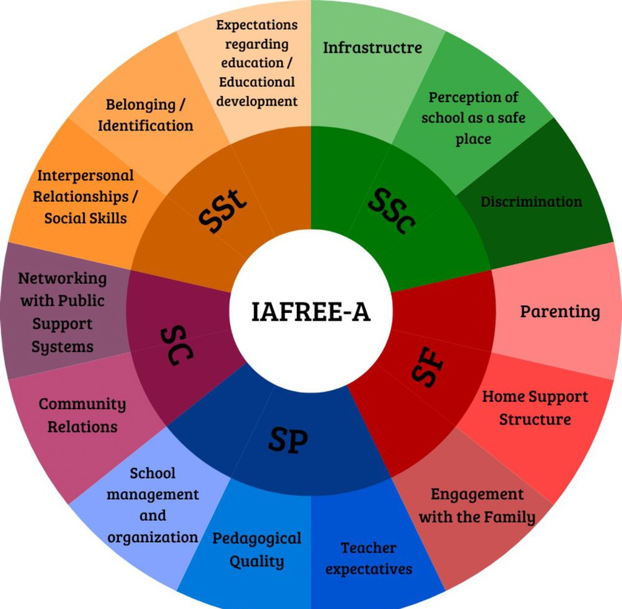

No es una lista de riesgos del estudiante: es un mapa de sus vínculos. Cinco dimensiones, catorce factores de atención, 46 ítems.

SSt**Estudiante–Estudiante** · pertenencia e identificación, relaciones interpersonales, expectativas sobre la educación

SSc**Estudiante–Escuela** · infraestructura, la escuela como espacio seguro, discriminación

SP**Estudiante–Profesionales** · expectativas docentes, calidad pedagógica, gestión y organización escolar

SF**Estudiante–Familia** · parentalidad, estructura de apoyo del hogar, articulación con la familia

SC**Estudiante–Comunidad** · relaciones con la comunidad, articulación con la red de apoyo

Ejemplo de ítem (escala de 1 a 4): *"Considero que los lugares para practicar deportes o actividades físicas en mi escuela son buenos"* — dimensión Estudiante–Escuela, factor infraestructura.

Instrumento de Avaliação dos Fatores de Risco de Evasão Escolar — Versão Alternativa (IAFREE-A). Más que diagnosticar causas del abandono: construir sistemas educativos protectores.

Leogildo · El instrumento

## Dos formatos, *todas las realidades*

[figure not shown]

Versión digital

[figure not shown]

Versión impresa (desconectada)

- **La versión impresa no es un detalle:** es lo que permite llegar a las múltiples realidades de las escuelas, con y sin conectividad.
- **El escore** de cada factor y dimensión es el promedio de sus ítems, de 1 a 4: el Índice de Percepción Estudiantil de Vulnerabilidad de la Trayectoria Escolar.

Leogildo · Validación

## Adaptado, aplicado y *psicométricamente verificado*

41.443

aplicaciones en total, en la familia IAFREE

3

países: Brasil, Chile y El Salvador

2

idiomas: portugués y español

Brasil: 22.618 (IAFREE 15.924 · IAFREE-R 983 · IAFREE-A 5.711, en dos aplicaciones) · Chile: 167 (IAFREE-R-ESP) · El Salvador: 18.658 (IAFREE-R-ES, dos recolecciones)

En cada adaptación, las propiedades psicométricas fueron verificadas: la estructura interna del modelo de medida se replica, con índices de ajuste satisfactorios y precisión adecuada de las puntuaciones.

Y una propiedad pensada para la equidad: los rangos bajo / medio / alto no son cortes fijos — son normativos por dimensión y sensibles a recortes de género, raza y nivel socioeconómico, porque grupos distintos tienen necesidades distintas de protección.

Leogildo · La recepción

## Cómo lo han recibido las redes

Donde ha llegado, el instrumento ha sido recibido como algo de mucha utilidad, por dos razones:

### 1 · Califica lo que ya hacen

Las escuelas y redes ya actúan para proteger trayectorias. El perfil organiza, fundamenta y da dirección a ese trabajo existente.

### 2 · Acerca la realidad de sus estudiantes

Permite ver de manera más próxima cómo los estudiantes experimentan la escuela, el aula, la familia y el territorio.

Y abre la pregunta que estructura la segunda parte: ¿qué pasa después de escuchar?

2

Segunda parte · Gabriel Fortes, PhD

## SPTE: del diagnóstico al apoyo a la intervención

Cómo se construyó el sistema: los argumentos detrás de cada elección de diseño.

Gabriel · Los argumentos

## Primer argumento: el problema *cambia de naturaleza* por el camino

TempranoTarde

1. Ausencia puntual

Se pierde contenido. No hay intención de dejar la escuela.

2. Contenido acumulado

La clase siguió. El regreso cuesta más que la ausencia.

3. Autoeficacia y autoconcepto

La dificultad se lee como incapacidad propia.

4. Expectativa de futuro

La escuela deja de parecer una vía hacia algo mejor.

5. Presión socioeconómica

Trabajar ahora rinde más que recuperar lo perdido.

6. Abandono

Decisión razonable dado lo acumulado.

#### Qué tiene que hacer la intervención aquí

Restituir la presencia y el contenido perdido antes de que la clase avance.

Aviso temprano, contacto inmediato, reposición puntual.

0 eslabones que deshacer5 aún evitables

**Un camino frecuente, no el único.** Los eslabones del medio son relacionales y subjetivos: exactamente lo que el IAFREE-A escucha. Si el problema cambia por el camino, **la respuesta tiene que poder variar**.

Goodman (2014), NBER WP 20221, con nevadas como variación exógena: la ausencia individual reduce el aprendizaje; el cierre coordinado, no · Marsh & Craven (2006) · Eccles & Wigfield (2002) · Jensen (2010), *QJE* 125(2).

Gabriel · Los argumentos

## Segundo argumento: mover el indicador *no garantiza* mover el desenlace

En el ensayo aleatorizado de Faria et al. (2017), sistema de alerta EWIMS:

73

escuelas aleatorizadas

Bajó

- Ausentismo crónico
- Reprobación de asignaturas

Sin efecto

- Promedio de notas
- Acumulación de créditos
- Suspensiones

Detectar sin apoyar la intervención puede mover la señal sin llegar al proceso. Por eso el SPTE no termina en la detección.

Faria et al. (2017). REL Midwest, Institute of Education Sciences.

Gabriel · Los argumentos

## Tercer argumento: predecir y decidir el tratamiento son *problemas distintos*

La distinción de Kleinberg, Ludwig, Mullainathan y Obermeyer (2015):

Problema de predicción

### ¿A quién?

Dirigir un recurso escaso. Lo que la detección responde.

Problema causal

### ¿Qué?

Qué tratamiento produce efecto. Lo que la detección no responde.

El modelo lógico del SPTE es una respuesta a esa brecha: cómo conectar la señal con la acción. Tres arquitecturas posibles, y una elección.

Kleinberg, Ludwig, Mullainathan & Obermeyer (2015). *AER: P&P*, 105(5).

Gabriel · El modelo lógico

La señal decide

## Gatillo

- **Qué es:** un indicador cruza un límite y dispara respuesta protocolizada. Inasistencia señalada → ida a terreno.
- **Tradición:** búsqueda activa en salud pública; FICAI y APOIA en Brasil; condicionalidades; Búsqueda Activa Escolar de UNICEF.
- **Límite estructural:** la señal ya es parte del desenlace. Opera tarde en la cascada: más remedial que preventivo. Sigue siendo necesario para quien ya salió.

Faria et al. (2017), REL Midwest · Devereux & Sabates-Wheeler (2004), IDS WP 232.

Gabriel · El modelo lógico

El instrumento decide

## Estratificación

- **Qué es:** un instrumento mide, unos cortes clasifican, cada clase recibe una ruta. Gordon: universal, selectiva, indicada.
- **Modo de falla:** según la evaluación nacional de RTI (Balu et al., 2015, regresión discontinua), los designados a intervención intensiva rindieron *peor*: la designación no implicaba recepción. En el ensayo TARGET, solo el 36% del brazo estratificado recibió el tratamiento correspondiente.
- El instrumento clasificaba; nadie decidía con él. La clasificación no es la decisión.

[figure not shown]

Gordon (1987) · Mrazek & Haggerty (1994), IOM · Balu et al. (2015), NCEE 2016-4000 · ensayo TARGET; revisión en *PAIN* (2024).

Gabriel · El modelo lógico

La unidad decide

## Portafolio

- **Qué es:** un catálogo de intervenciones; cada red elige según su contexto. Repositorios de evidencia, programas de adhesión.
- **Fundamento:** la adopción depende de la apropiación local. El respeto ecológico es condición de eficacia, no concesión.
- **Riesgo:** elige mejor quien ya podía elegir. Sin acoplamiento, la red elige lo que ya iba a elegir y no queda registro.

Wandersman et al. (2008), *Am J Community Psychol* 41 · Chinman, Imm & Wandersman, Getting To Outcomes, RAND.

Gabriel · La elección brasileña

## La elección brasileña: *dar voz* a la comunidad escolar

- **Encaminamiento después de la escucha:** del diagnóstico, un menú acotado de acciones sugeridas, vinculadas al factor de atención — detección estratificada con respuesta en portafolio.
- **Una perspectiva ética sobre el gobierno central:** el nivel central estructura, sugiere y sostiene; no decide por las comunidades escolares. Las acciones sugeridas son orientadoras y deben adaptarse a cada realidad.
- **Y la voz vuelve al territorio:** las redes registran las acciones que ya realizan, que pasan a inspirar a otras escuelas.

Gabriel · El sistema

## El ciclo del SPTE

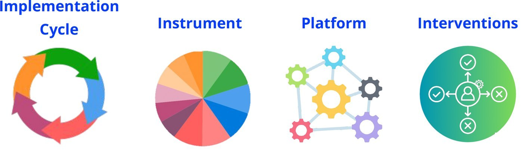

- **Escucha → localiza → actúa:** el instrumento escucha; la plataforma localiza; las intervenciones actúan — y el ciclo de implementación vuelve a escuchar.
- **Modelo híbrido, psicometría + tecnología,** con versión desconectada para las escuelas donde lo digital no llega.

Gabriel · El sistema

## La plataforma: de la dimensión *al factor*

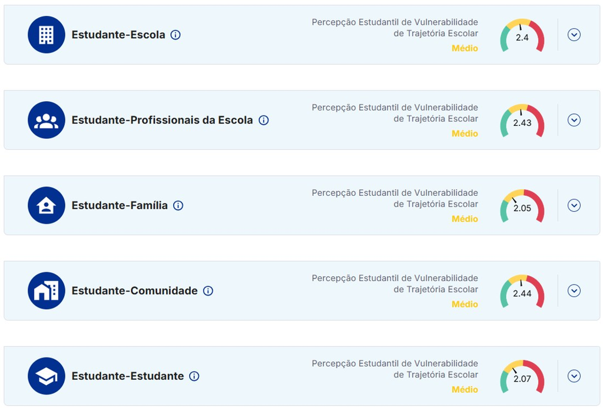

Lectura inicial por dimensión: la relación del estudiante con cada ente de la comunidad escolar

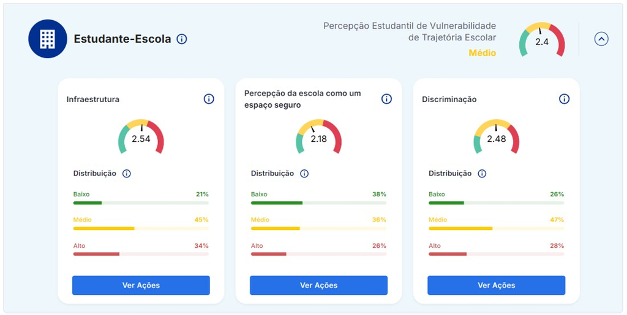

Al expandir: el promedio por factor y la distribución de estudiantes en bajo / medio / alto

- **Niveles de visualización:** aula, escuela, municipio y estado — cada instancia de gestión ve el nivel que le corresponde y decide en su escala.
- **Rangos normativos, no fijos:** bajo / medio / alto se leen por dimensión y por recortes de género, raza y nivel socioeconómico.

Gabriel · El sistema

## La ficha de plan de acción: el acoplamiento *hecho documento*

La plataforma sugiere acciones vinculadas al factor de atención, y cada elección o acción propia de la escuela queda registrada con la misma estructura.

Ficha de plan de acción · SPTE

Dimensión / factor

Estudiante–Escuela · La escuela como espacio seguro

Nombre de la acción

Círculo de paz: escucha, respeto y seguridad

Descripción

*resumen de la acción a realizar*

Objetivos

*objetivos específicos a alcanzar con la acción*

Estrategias

*las acciones en detalle*

Responsables

*cargo, persona o grupo que realizará la acción*

Indicadores de monitoreo

*cómo se acompaña la acción*

El registro es lo que vuelve la decisión observable — la condición para que el sistema aprenda de sí mismo.

Gabriel · El modelo lógico, en funcionamiento

## La asignación, con las cinco dimensiones del IAFREE-A

Perfil de protección de la escuela

Estudiante–Estudiante55

Estudiante–Escuela32

Est.–Profesionales48

Estudiante–Familia38

Estudiante–Comunidad60

Modelo de asignación

El diagnóstico ordena y recorta. La escuela elige dentro del subconjunto y registra la elección en la ficha.

Catálogo de acciones locales

Tutoría entre pares

preventivaselectiva

Círculos de convivencia

promotivauniversal

Círculo de paz: escucha, respeto y seguridad

promotivauniversal

Protocolo de acogida y pertenencia

preventivaselectiva

Mentoría docente asignada

preventivaindicada

Formación en calidad pedagógica

promotivauniversal

Escuela de familias

promotivauniversal

Visita domiciliaria

protectoraindicada

Alianzas con el territorio

promotivauniversal

Pertinencia = brecha del factor de protección asociado. Regla ilustrativa de acoplamiento, no un resultado medido.

Gabriel · Salvaguardas

## Tres salvaguardas para que el instrumento *sobreviva al uso*

Conflicto diagnóstico-alocativo

Si el escore asigna recursos o evalúa, hay incentivo a declarar estratégicamente. Anticiparlo es diseño, no desconfianza.

Respuesta antes que medida

Un escore bajo debe traer apoyo, no penalización. No medir lo que no se está preparado para responder.

Desagregación como calidad

¿Quién desaparece en el promedio? El SPTE ya lo asume: los rangos se leen por dimensión y por recortes de género, raza y nivel socioeconómico.

Campbell (1979). *Evaluation and Program Planning*, 2(1) — cuanto más se usa un indicador para decidir, mayor la presión de distorsión sobre él.

Gabriel · Diseño

## Prevención y promoción, *por regla y no por residuo*

- Un menú ordenado solo por brecha converge hacia lo deteriorado: **la promoción no tiene señal, y por eso nunca gana**. Es propiedad de la arquitectura, no de las intenciones.
- **Rose (1985):** la mayoría de los casos proviene de la mayoría de bajo riesgo. Focalizar solo en la cola tiene alcance limitado.
- **Corrección:** indexar por nivel y por función, y reservar posiciones. El instrumento decide *cuál*, no *cuántas*.

Un sistema robusto fomenta prevención y promoción de manera consciente.

Rose (1985), *Int J Epidemiol* 14(1) · Devereux & Sabates-Wheeler (2004), IDS WP 232 · Gordon (1987) · Mrazek & Haggerty (1994).

Cierre

## Las trayectorias se protegen *en el tiempo*

Una trayectoria escolar se protege a lo largo de años, y los desenlaces también necesitan tiempo para mostrarse. Lo que ya podemos informar: donde el SPTE llega, la relación con la gestión y con la comunidad escolar ha sido muy buena — el sistema califica lo que las redes ya hacen y les permite ver más de cerca a sus estudiantes.

**Gracias**Leogildo Alves Freires, PhD · Gabriel Fortes, PhD — Universidade Federal de Alagoas

## ¡Muchas *gracias!*

**Leogildo Alves Freires, PhD**leogildo.freires@nees.ufal.br

**Gabriel Fortes, PhD**gabriel.macedo@nees.ufal.br

[figure not shown]